# Análisis Integrado de Vulnerabilidades en los Sistemas de Salud y Emergencias en la República Argentina (2020–2025)

Crisis pandémica, transición de paradigmas sanitarios y gobernanza internacional en un contexto de policrisis global.

Egea, Sebastián , Benegas, Marcia , Ristagno, Ingacio , Simonovich, Jael , Gonzalez, Gonzalo , Investigación en Salud Pública y Políticas Sanitarias , Facultad de Ingeniería- Universidad Nacional de Cuyo , true  
2026-06-09

## Introducción

La pandemia de COVID-19 (2020) operó como acelerador de múltiples crisis preexistentes, evidenciando las contradicciones estructurales de los sistemas sanitarios contemporáneos. Diversos autores señalan que el modelo económico desregulado dejó consecuencias severas en los países que lo adoptaron como eje único de su política, registrándose las mayores tasas de mortalidad en los países del Norte Global (Córdova & Linares, 2020). El presente trabajo analiza, en tercera persona y con un enfoque cuantitativo y cualitativo, las vulnerabilidades de los sistemas de salud y emergencias de la República Argentina entre 2020 y 2025, articulando la dimensión global (pandemia, gobernanza internacional y límites planetarios) con la dimensión local (estructura sanitaria, paradigmas, industria farmacéutica y vulnerabilidades de los servicios de emergencia).

## Dimensión Global

### COVID-19 y sistemas sanitarios

El análisis comparativo de los primeros 36 días de pandemia muestra diferencias marcadas en las tasas de recuperación y mortalidad entre países con distintos sistemas económico-políticos (Córdova & Linares, 2020). La Figura 1 sintetiza esta comparación.

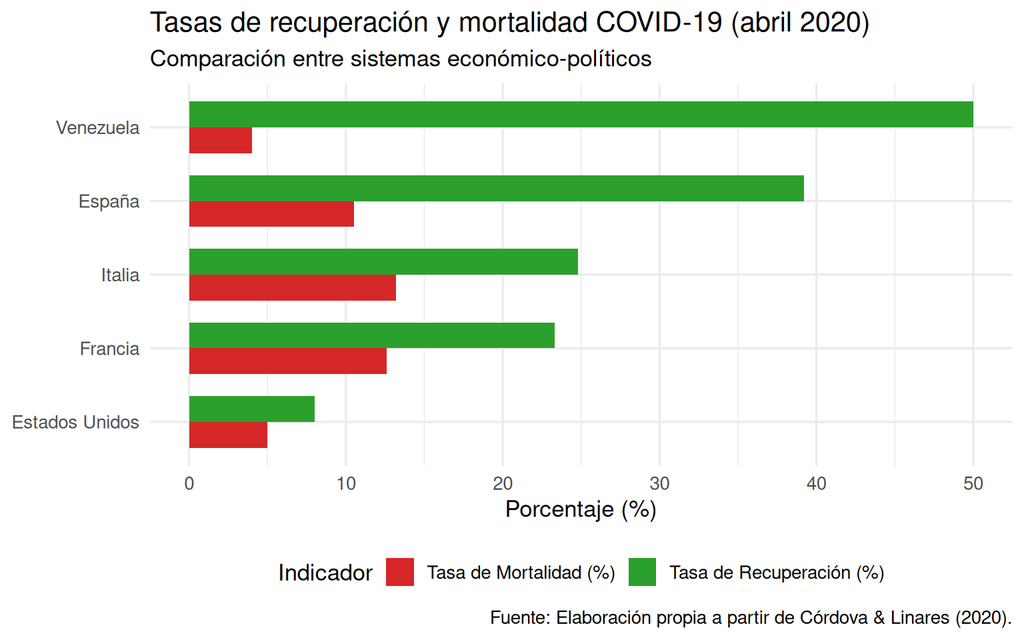

Figure 1: Tasas de recuperación y mortalidad por COVID-19 según sistema económico-político (abril 2020).

### Gobernanza internacional y retiro de organismos de salud

La policrisis y la entropía caracterizan el sistema internacional contemporáneo, donde múltiples crisis convergen de manera simultánea. En este entorno, el Derecho Internacional enfrenta el doble desafío del cuestionamiento de los compromisos internacionales y el creciente escepticismo hacia el multilateralismo (Bas Vilizzio, 2025; Ghiggino, 2025). La Tabla 1 sintetiza los retiros recientes de Estados miembros de organismos internacionales con impacto en la gobernanza sanitaria.

Table 1: Table 2: Retiros de organismos internacionales vinculados a salud (2007–2025).

| País | Organismo | Año | Contexto | Efecto Contagio |
| --- | --- | --- | --- | --- |
| Estados Unidos | OMS | 2025 | Policrisis — multilateralismo cuestionado | Argentina inicia análisis de retiro |
| Estados Unidos | UNESCO | 2025 | Política exterior ‘America First’ | N/A |
| Bolivia | CIADI | 2007 | Soberanía sobre recursos naturales | Precedente regional |
| Venezuela | CIADI | 2012 | Soberanía — modelo bolivariano | Reconfiguración jurídica regional |
| Honduras | CIADI | 2024 | Disputas inversor-Estado | En evaluación |

### Límites planetarios y salud

La transgresión de los límites planetarios erosiona las capacidades estatales e incrementa la probabilidad de conflictos territoriales, con repercusiones directas sobre la salud poblacional; seis de los nueve límites ya habrían sido superados (Rockström et al., 2009; Rodríguez Tornquist & Lacapmesure, s.f.). La Figura 2 ordena los límites según su nivel de riesgo sanitario.

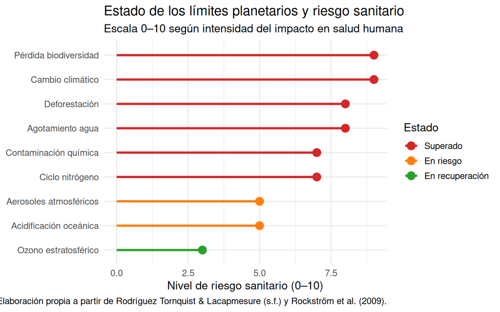

Figure 2: Estado de los límites planetarios y su impacto en los sistemas de salud.

## Dimensión Local: Argentina

### Estructura del sistema sanitario

El sistema de salud argentino se organiza en tres subsectores —público, de obras sociales y privado— con coberturas y lógicas de financiamiento heterogéneas, según se detalla en la Tabla 2.

Table 3: Table 4: Estructura del sistema de salud argentino por subsector (2024).

| Subsector | Cobertura (%) | Financiamiento | Característica |
| --- | --- | --- | --- |
| Público | 36 | Estado Nacional y Provincial | Gratuito y universal |
| Obras Sociales (PAMI + Sindicales) | 46 | Aportes laborales | Basado en trabajo formal |
| Privado / Prepagas | 18 | Gasto de bolsillo | Mercantilizado |

### Paradigmas sanitarios y crisis

Se identifican seis etapas históricas en la evolución de los modelos sanitarios, desde el Paleolítico hasta la emergente propuesta de salud integrativa sistémica, mostrando cómo cada modelo fue moldeado por movimientos económicos, sociales y culturales específicos (Bongioanni, 2025). La Figura 3 representa el índice de integración sistémica a lo largo de esas etapas.

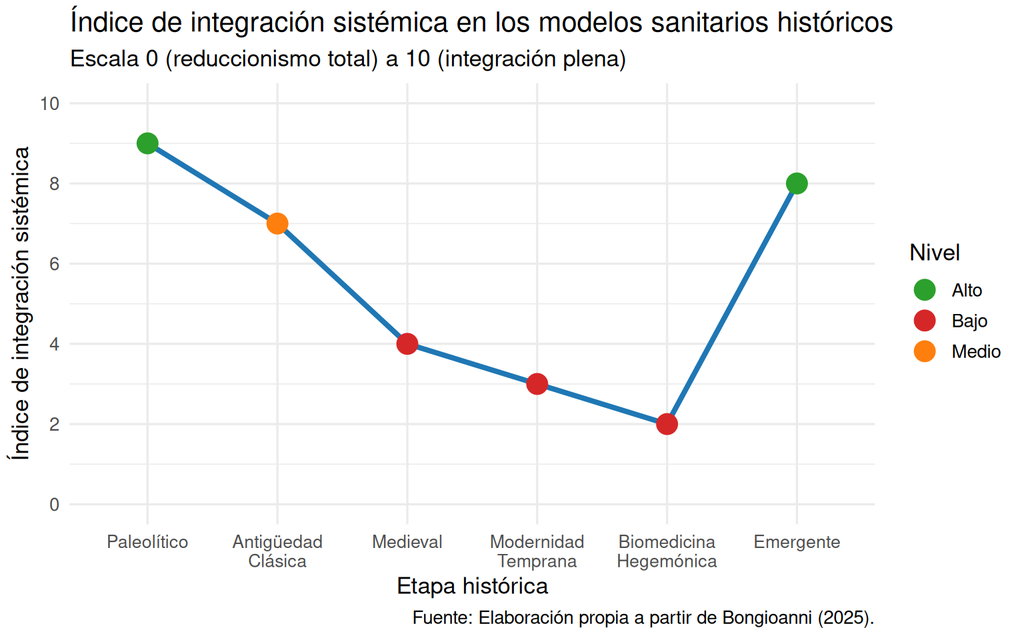

Figure 3: Índice de integración sistémica según etapas históricas del modelo sanitario.

La Tabla 3 compara las dimensiones centrales del modelo biomédico hegemónico frente al modelo de salud integrativa sistémica.

Table 5: Table 6: Análisis comparativo entre paradigmas sanitarios (Bongioanni, 2025).

| Dimensión | Modelo Biomédico | Modelo Integrativo Sistémico |
| --- | --- | --- |
| Epistemología | Monocausal | Pluricausal |
| Enfoque clínico | Patogénico | Salutogénico |
| Gestión del conocimiento | Jerarquizado | Intercultural |
| Organización sanitaria | Mercantilizada | Comunitaria |
| Relación con el ambiente | Desvinculado | Integrado |
| Uso del medicamento | Racional (protocolar) | Consciente (crítico, desprescripción) |

### Industria farmacéutica y farmacontaminación

La industria farmacéutica en Argentina registró un incremento del 74,3 % en su facturación durante el último año (Instituto Nacional de Estadística y Censos (INDEC), 2025), en paradójica contradicción con el deterioro de los indicadores de salud poblacional; este crecimiento no respondería a un mayor poder adquisitivo, sino a la proliferación de demandas de intervención farmacológica (Bongioanni, 2025). La Figura 4 ilustra esta paradoja.

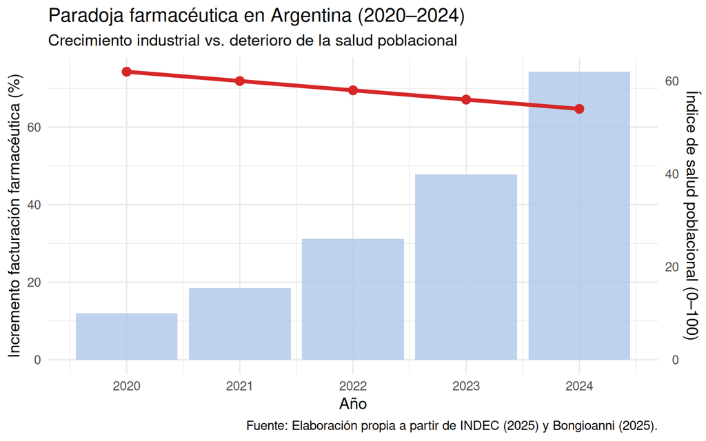

Figure 4: Paradoja farmacéutica: crecimiento de la industria vs. deterioro del índice de salud poblacional (2020–2024).

### Vulnerabilidades del sistema de emergencias

La crisis sistémica contemporánea expone múltiples vulnerabilidades en los servicios de emergencia sanitaria, afectados tanto por factores endógenos (recorte presupuestario, desigualdad de cobertura) como exógenos (retiro de organismos internacionales, farmacontaminación, cambio climático) (Bas Vilizzio, 2025; Bongioanni, 2025; Córdova & Linares, 2020). La Figura 5 ordena estas vulnerabilidades por nivel de riesgo.

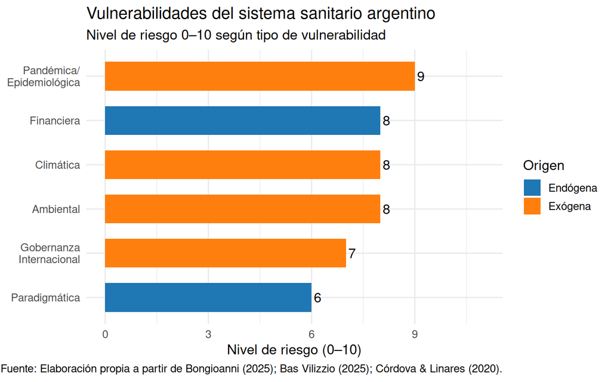

Figure 5: Nivel de riesgo por tipo de vulnerabilidad en el sistema de salud y emergencias de Argentina.

## Conclusiones y Recomendaciones

El análisis integrado revela que las vulnerabilidades de los sistemas de salud y emergencias argentinos no son atribuibles a un único factor, sino a la convergencia de presiones globales (policrisis, retiro del multilateralismo, transgresión de límites planetarios) y locales (fragmentación del sistema, hegemonía del modelo biomédico y farmacontaminación). Como horizonte de respuesta se propone la transición del paradigma biomédico hegemónico hacia un **Modelo de Salud Integrativa Sistémica** que articule perspectivas decoloniales, sostenibilidad ambiental y enfoques participativos (Bongioanni, 2025). Esa transición puede ordenarse en tres fases: (1) **diagnóstico crítico** —mapeo de farmacontaminación, auditoría de cobertura territorial e identificación de determinantes estructurales—; (2) **transición paradigmática** —incorporación de medicina integrativa en el sistema público, reconocimiento de saberes ancestrales y uso consciente del medicamento—; y (3) **institucionalización** —reformulación de políticas públicas, reanudación de compromisos internacionales y desarrollo de sistemas sanitarios ambientalmente sustentables.

A efectos de monitoreo, se sugieren los siguientes indicadores de sostenibilidad:

- Huella de carbono por cama hospitalaria bajo esquemas de cogeneración renovable.
- Análisis de ciclo de vida (LCA) comparativo entre el modelo biomédico hegemónico y el modelo de salud integrativa sistémica ante escenarios de policrisis.
- Resiliencia de la cadena de suministro farmacéutico frente al retiro de organismos internacionales de salud.
- Índice de farmacontaminación en cuencas hídricas urbanas y rurales de Argentina.
- Cobertura efectiva de sistemas de alerta temprana ante emergencias sanitarias de origen zoonótico y climático.

## Referencias

Bas Vilizzio, M. (2025). ¿Del multilateralismo al “primero yo”? Sobre el retiro de los miembros de las organizaciones internacionales en tiempos de policrisis. *Revista Electrónica de Estudios Internacionales*, *50*. https://doi.org/10.36151/reei.50.10

Bongioanni, A. (2025). Repensando la salud en tiempos de colapso: hacia un paradigma integrativo. *Bitácora Digital*, *12*(16), 77–88.

Córdova, V., & Linares, A. (2020). El coronavirus y la pandemia: una crónica sociosimbólica. *Revista Del Instituto de Altos Estudios de La Seguridad de La Nación*, *5*(1), 55–67.

Ghiggino, G. (2025). Tensiones y cambios en el orden internacional de post Guerra Fría. *Studia Politicæ*, (64), 42–62. https://doi.org/10.22529/sp.2025.64.02

Instituto Nacional de Estadística y Censos (INDEC). (2025). *Industria farmacéutica en la Argentina. Primer Trimestre de 2025* (Vol. 9 N° 148). Ministerio de Economía de la Nación Argentina.

Rockström, J., Steffen, W. L., Noone, K., Persson, Å., Stuart Chapin, F., Lambin, E., et al. (2009). Planetary Boundaries: Exploring the Safe Operating Space for Humanity. *Ecology and Society*, *14*(2), 32.

Rodríguez Tornquist, R., & Lacapmesure, F. (s.f.). *Los desafíos de la democracia ambiental para la transición ecológica justa*. Fundación Revolución 21 / Asociación Sustentar.